# Final Assignment

Matthias Aulbach

08.03.2017

# Abstract

# Description of the dataset

Thi dataset comes from an intervention study with depression patients. Each patient had several sessions with a therapist in each of which they set three goals. These goals are the focus of my analysis: every case represents a goal (not a patient). The goal content was coded into binary variables (since some goals belong to more than one category). In addition, we have here the standardized goal progress and an entry and end score for depression symptoms. I also created a variable that indicates changes in depression scores and a binary variable that tells us whether or not a patient was above the cutoff value of the depression questionnaire at the end of the treatment (see the data wrangling script). Therapists are coded into a categorical variable.

# Research questions:

1. Does the kind of goal that has been set have an influence on a) goal progress and b) symptom change? My hypothesis is that goal content does make a difference, i.e. some kinds of goals lead to more progress and larger symptom change.
2. Do the therapists differ in their effectiveness regarding a) goal progress and b) symptom change? Also for therapists, I expect differences since surely, not all therapists are equally qualified.
3. Does it depend on the therapist which kind of goal is chosen? Again, my hypothesis is that therapists have “favourites” regarding goal content, i.e. that there are differences in goal content depending on the therapist.

# Getting the data file and summary

```r
Goals <- read.table("Goals")
colnames(Goals)
```

```
##  [1] "pagol"             "dietgol"           "alcogol"
##  [4] "addictgol"         "sleepgol"          "relaxgol"
##  [7] "socgol"            "emogol"            "coggoal"
## [10] "workgoal"          "homegoal"          "hobgoal"
## [13] "hygmdgol"          "treatgol"          "badgoal"
## [16] "assgoal"           "reenggol"          "unclearg"
## [19] "therapist"         "zgoalprogress"     "phqentry"
## [22] "phqend"            "goalprogress_full" "phq_change"
## [25] "depr"
```

```r
str(Goals)
```

```
## 'data.frame':    828 obs. of  25 variables:
##  $ pagol            : logi  FALSE FALSE FALSE FALSE FALSE FALSE ...
##  $ dietgol          : logi  FALSE FALSE FALSE FALSE FALSE FALSE ...
##  $ alcogol          : logi  FALSE FALSE FALSE FALSE FALSE FALSE ...
##  $ addictgol        : logi  FALSE FALSE FALSE FALSE FALSE FALSE ...
##  $ sleepgol         : logi  FALSE FALSE FALSE FALSE FALSE FALSE ...
##  $ relaxgol         : logi  FALSE FALSE FALSE FALSE FALSE FALSE ...
##  $ socgol           : logi  FALSE FALSE TRUE FALSE FALSE TRUE ...
##  $ emogol           : logi  FALSE FALSE FALSE FALSE FALSE FALSE ...
##  $ coggoal          : logi  FALSE FALSE FALSE FALSE FALSE FALSE ...
##  $ workgoal         : logi  FALSE FALSE FALSE FALSE FALSE FALSE ...
##  $ homegoal         : logi  FALSE FALSE FALSE FALSE FALSE FALSE ...
##  $ hobgoal          : logi  FALSE FALSE FALSE FALSE FALSE FALSE ...
##  $ hygmdgol         : logi  FALSE FALSE FALSE FALSE FALSE FALSE ...
##  $ treatgol         : logi  TRUE FALSE FALSE TRUE FALSE FALSE ...
##  $ badgoal          : logi  FALSE FALSE FALSE FALSE FALSE FALSE ...
##  $ assgoal          : logi  FALSE FALSE FALSE FALSE FALSE FALSE ...
##  $ reenggol         : logi  FALSE FALSE FALSE FALSE FALSE FALSE ...
##  $ unclearg         : logi  FALSE FALSE FALSE FALSE FALSE FALSE ...
##  $ therapist        : Factor w/ 18 levels "AC","BD","CM",..: 5 5 5 5 5 5 5 5 5 12 ...
##  $ zgoalprogress    : num  0.6188 0.0204 0.9608 0.1628 0.4763 ...
##  $ phqentry         : int  24 24 24 24 24 24 24 24 24 19 ...
##  $ phqend           : int  3 3 3 3 3 3 3 3 3 19 ...
##  $ goalprogress_full: int  82 61 94 66 77 98 87 85 98 39 ...
##  $ phq_change       : int  21 21 21 21 21 21 21 21 21 0 ...
##  $ depr             : logi  FALSE FALSE FALSE FALSE FALSE FALSE ...
```

```r
summary(Goals)
```

```
##    pagol          dietgol         alcogol        addictgol
##  Mode :logical   Mode :logical   Mode :logical   Mode :logical
##  FALSE:707       FALSE:800       FALSE:825       FALSE:818
##  TRUE :121       TRUE :28        TRUE :3         TRUE :10
##  NA's :0         NA's :0         NA's :0         NA's :0
##
##
##
##   sleepgol        relaxgol         socgol          emogol
##  Mode :logical   Mode :logical   Mode :logical   Mode :logical
##  FALSE:798       FALSE:798       FALSE:700       FALSE:791
##  TRUE :30        TRUE :30        TRUE :128       TRUE :37
##  NA's :0         NA's :0         NA's :0         NA's :0
##
##
##
##   coggoal         workgoal        homegoal        hobgoal
##  Mode :logical   Mode :logical   Mode :logical   Mode :logical
##  FALSE:796       FALSE:754       FALSE:711       FALSE:754
##  TRUE :32        TRUE :74        TRUE :117       TRUE :74
##  NA's :0         NA's :0         NA's :0         NA's :0
##
##
##
##   hygmdgol        treatgol        badgoal         assgoal
##  Mode :logical   Mode :logical   Mode :logical   Mode :logical
##  FALSE:810       FALSE:669       FALSE:793       FALSE:801
##  TRUE :18        TRUE :159       TRUE :35        TRUE :27
##  NA's :0         NA's :0         NA's :0         NA's :0
##
##
##
##   reenggol        unclearg         therapist   zgoalprogress
##  Mode :logical   Mode :logical   JS     :162   Min.   :-1.7180
##  FALSE:807       FALSE:735       LG     :162   1st Qu.:-0.8702
##  TRUE :21        TRUE :93        HD     :144   Median : 0.2483
##  NA's :0         NA's :0         JL     : 63   Mean   : 0.0178
##                                  LB     : 54   3rd Qu.: 0.9893
##                                  GF     : 27   Max.   : 1.1318
##                                  (Other):216   NA's   :160
##     phqentry         phqend       goalprogress_full   phq_change
##  Min.   : 9.00   Min.   : 0.000   Min.   :  0.00    Min.   :-4.000
##  1st Qu.:13.00   1st Qu.: 4.000   1st Qu.:  3.00    1st Qu.: 4.000
##  Median :17.00   Median : 8.000   Median : 51.00    Median : 8.500
##  Mean   :16.99   Mean   : 8.543   Mean   : 49.14    Mean   : 8.446
##  3rd Qu.:21.00   3rd Qu.:11.000   3rd Qu.: 90.00    3rd Qu.:12.250
##  Max.   :26.00   Max.   :23.000   Max.   :100.00    Max.   :21.000
##
##     depr
##  Mode :logical
##  FALSE:567
##  TRUE :261
##  NA's :0
##
##
##
```

The goals set most often are physical activity related, from the social domain (such as meeting with friends), related to the home or somehow connected to the treatment. Goals related to alcohol consumption or other addictive behaviors are very rare. PHQ (i.e. depression) scores range from 9 (surprising, since 10 is the cutof value) to 26, which is extremely high. On average, patients had a score of 17, indicating a “moderately severe depression”. At the end of treatment, average PHQ scores were at 8.5. which is under the cutoff for a clinically significant depression. On average, PHQ scores decreased by 8.4 points. However, 261 patients (more than a quarter) were still considered as having a depression at the end of treatment.

## Relations between variables

Let’s take a look at relations between some of our variables.

```r
reg1 <- lm(phqentry ~ phqend, data = Goals)
summary(reg1)
```

```
##
## Call:
## lm(formula = phqentry ~ phqend, data = Goals)
##
## Residuals:
##     Min      1Q  Median      3Q     Max
## -8.1019 -3.3609 -0.0778  3.3951  8.3800
##
## Coefficients:
##             Estimate Std. Error t value Pr(>|t|)
## (Intercept) 14.87899    0.27054  54.997   <2e-16 ***
## phqend       0.24699    0.02673   9.241   <2e-16 ***
## ---
## Signif. codes:  0 '***' 0.001 '**' 0.01 '*' 0.05 '.' 0.1 ' ' 1
##
## Residual standard error: 4.175 on 826 degrees of freedom
## Multiple R-squared:  0.09369,    Adjusted R-squared:  0.0926
## F-statistic: 85.39 on 1 and 826 DF,  p-value: < 2.2e-16
```

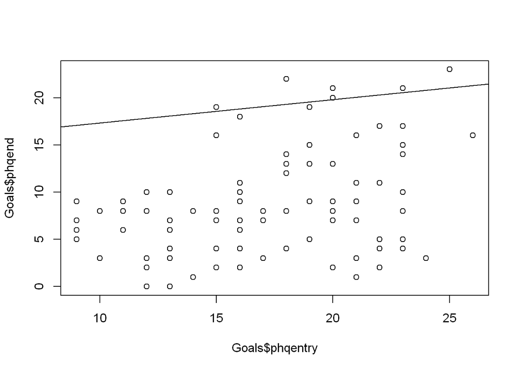

```r
plot(Goals$phqentry, Goals$phqend)
abline(reg1)
```

“phqentry”" and “phqend”" are correlated. This was to be expected when assuming that most patients’ score goes down a certain amount of points. Someone who has a very severe depression in the beginning still has more symptoms in the end while a mild depression in the beginning might be cured after therapy.

```r
reg2 <- lm(phqentry ~ zgoalprogress, data=Goals)
summary(reg2)
```

```
##
## Call:
## lm(formula = phqentry ~ zgoalprogress, data = Goals)
##
## Residuals:
##     Min      1Q  Median      3Q     Max
## -7.9806 -3.9476 -0.2659  4.0343  9.4446
##
## Coefficients:
##               Estimate Std. Error t value Pr(>|t|)
## (Intercept)    16.8117     0.1707  98.482   <2e-16 ***
## zgoalprogress   0.1492     0.1722   0.867    0.386
## ---
## Signif. codes:  0 '***' 0.001 '**' 0.01 '*' 0.05 '.' 0.1 ' ' 1
##
## Residual standard error: 4.411 on 666 degrees of freedom
##   (160 observations deleted due to missingness)
## Multiple R-squared:  0.001126,   Adjusted R-squared:  -0.0003734
## F-statistic: 0.751 on 1 and 666 DF,  p-value: 0.3865
```

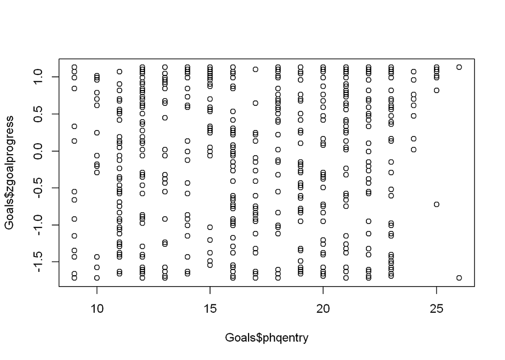

```r
plot(Goals$phqentry, Goals$zgoalprogress)
abline(reg2)
```

“phqentry”" and goal progress are not correlated. No matter how depressed a person was at the outset, the goal progress is more or less the same.

```r
reg4 <- lm(zgoalprogress ~ phqend, data = Goals)
summary(reg4)
```

```
##
## Call:
## lm(formula = zgoalprogress ~ phqend, data = Goals)
##
## Residuals:
##     Min      1Q  Median      3Q     Max
## -1.7641 -0.9138  0.2329  0.9525  1.1838
##
## Coefficients:
##              Estimate Std. Error t value Pr(>|t|)
## (Intercept)  0.055427   0.070990   0.781    0.435
## phqend      -0.004672   0.007414  -0.630    0.529
##
## Residual standard error: 0.9924 on 666 degrees of freedom
##   (160 observations deleted due to missingness)
## Multiple R-squared:  0.0005959,  Adjusted R-squared:  -0.0009047
## F-statistic: 0.3971 on 1 and 666 DF,  p-value: 0.5288
```

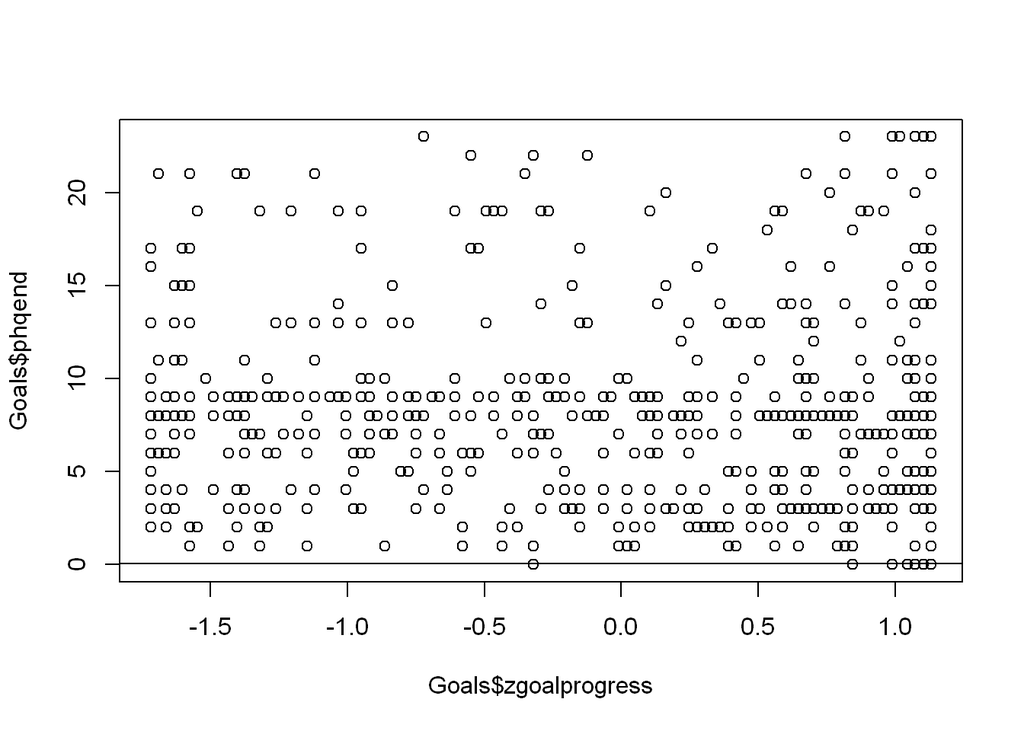

```r
plot(Goals$zgoalprogress, Goals$phqend)
abline(reg4)
```

“phqend”" and goal progress are not correlated. Obviously, making progress on one’s goals doesn’t help cure depressive symptoms.

```r
reg5 <- lm(zgoalprogress ~ phq_change, data = Goals)
summary(reg5)
```

```
##
## Call:
## lm(formula = zgoalprogress ~ phq_change, data = Goals)
##
## Residuals:
##     Min      1Q  Median      3Q     Max
## -1.7788 -0.8823  0.2266  0.9616  1.2024
##
## Coefficients:
##              Estimate Std. Error t value Pr(>|t|)
## (Intercept) -0.054190   0.069897  -0.775    0.438
## phq_change   0.008218   0.006669   1.232    0.218
##
## Residual standard error: 0.9916 on 666 degrees of freedom
##   (160 observations deleted due to missingness)
## Multiple R-squared:  0.002274,   Adjusted R-squared:  0.0007764
## F-statistic: 1.518 on 1 and 666 DF,  p-value: 0.2183
```

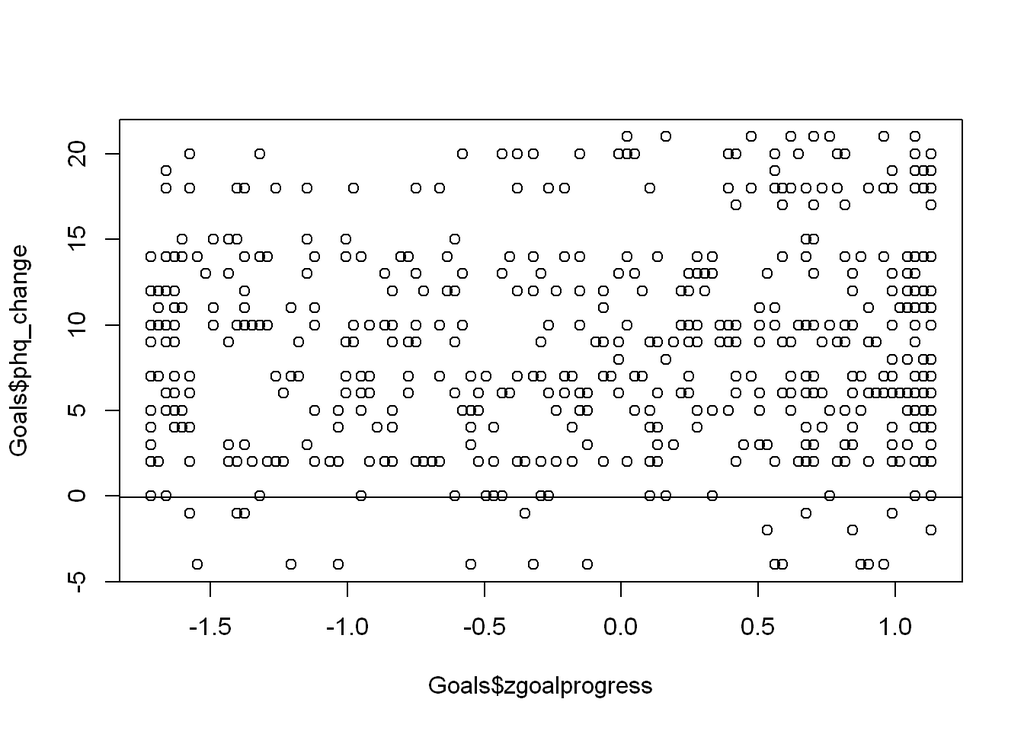

```r
plot(Goals$zgoalprogress, Goals$phq_change)
abline(reg5)
```

Logically, “phq_change”" is not correlated with goal progress either (since phq_change is made up of phqentry and phqend).

What’s also interesting for a start is how often the goals types were set. Let’s see a summary:

```r
summary(Goals[1:18])
```

```
##    pagol          dietgol         alcogol        addictgol
##  Mode :logical   Mode :logical   Mode :logical   Mode :logical
##  FALSE:707       FALSE:800       FALSE:825       FALSE:818
##  TRUE :121       TRUE :28        TRUE :3         TRUE :10
##  NA's :0         NA's :0         NA's :0         NA's :0
##   sleepgol        relaxgol         socgol          emogol
##  Mode :logical   Mode :logical   Mode :logical   Mode :logical
##  FALSE:798       FALSE:798       FALSE:700       FALSE:791
##  TRUE :30        TRUE :30        TRUE :128       TRUE :37
##  NA's :0         NA's :0         NA's :0         NA's :0
##   coggoal         workgoal        homegoal        hobgoal
##  Mode :logical   Mode :logical   Mode :logical   Mode :logical
##  FALSE:796       FALSE:754       FALSE:711       FALSE:754
##  TRUE :32        TRUE :74        TRUE :117       TRUE :74
##  NA's :0         NA's :0         NA's :0         NA's :0
##   hygmdgol        treatgol        badgoal         assgoal
##  Mode :logical   Mode :logical   Mode :logical   Mode :logical
##  FALSE:810       FALSE:669       FALSE:793       FALSE:801
##  TRUE :18        TRUE :159       TRUE :35        TRUE :27
##  NA's :0         NA's :0         NA's :0         NA's :0
##   reenggol        unclearg
##  Mode :logical   Mode :logical
##  FALSE:807       FALSE:735
##  TRUE :21        TRUE :93
##  NA's :0         NA's :0
```

# Data Analysis

## 1. a) Relation between goal content and goal progress

First, I want to investigate whether goals differ in regard to the progress that patients make in them. To study this, I will plot the different goals against “zgoalprogress”" (Note that “zgoalprogress” is a standardized value).

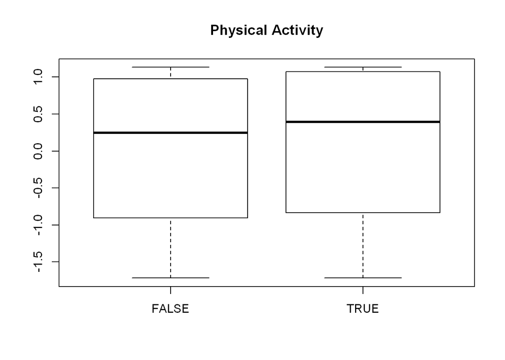

```r
boxplot(Goals$zgoalprogress ~ Goals$pagol, main = "Physical Activity")
```

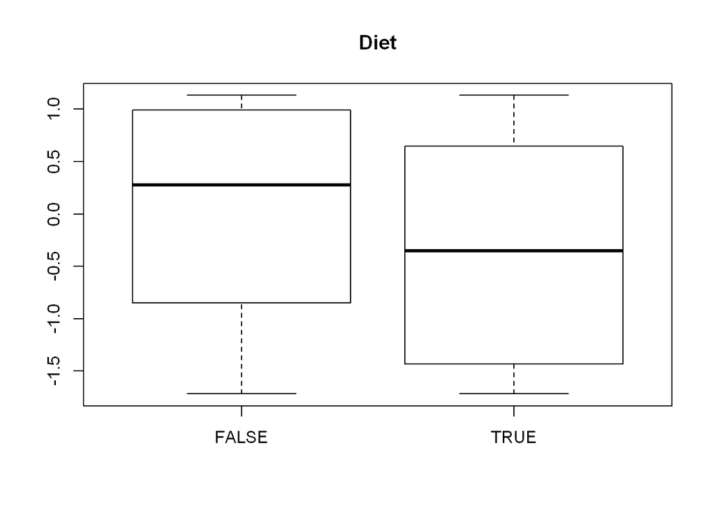

```r
boxplot(Goals$zgoalprogress ~ Goals$dietgol, main = "Diet")
```

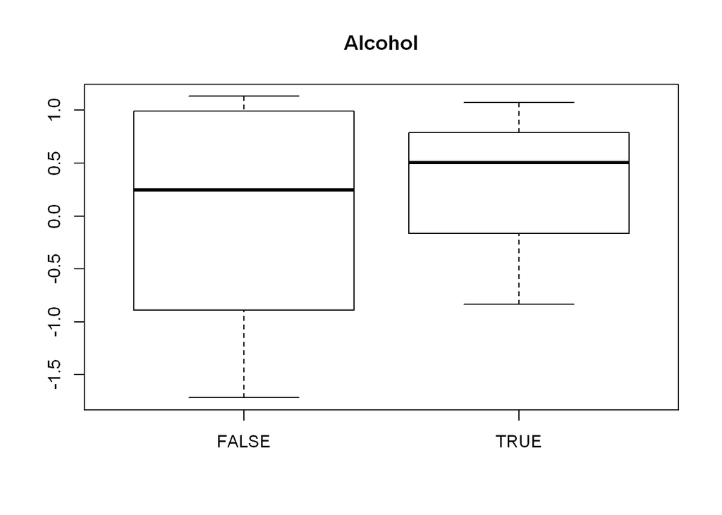

```r
boxplot(Goals$zgoalprogress ~ Goals$alcogol, main = "Alcohol")
```

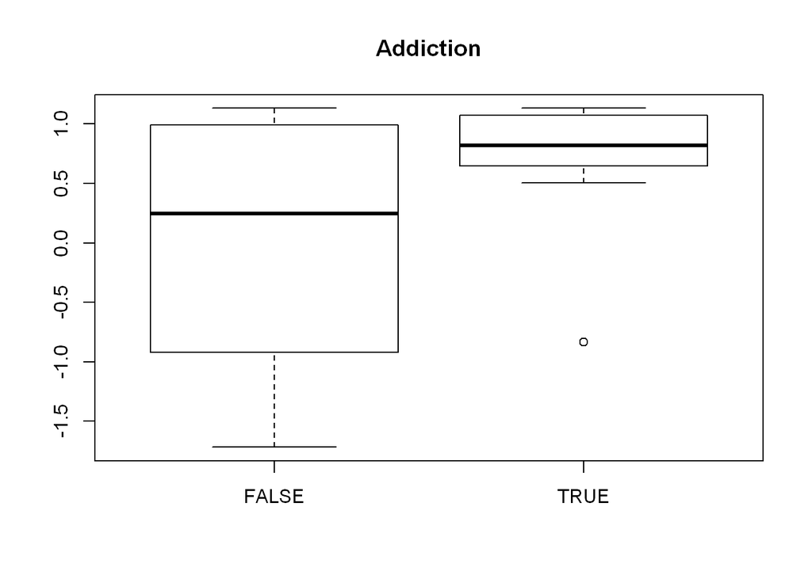

```r
boxplot(Goals$zgoalprogress ~ Goals$addictgol, main = "Addiction")
```

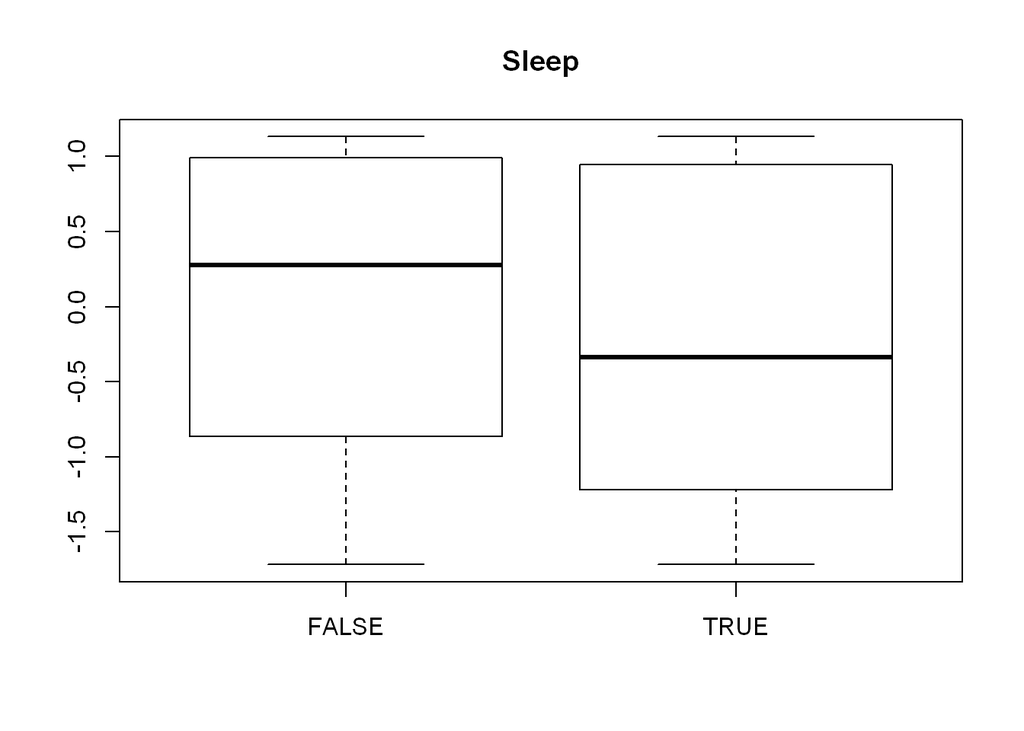

```r
boxplot(Goals$zgoalprogress ~ Goals$sleepgol, main = "Sleep")
```

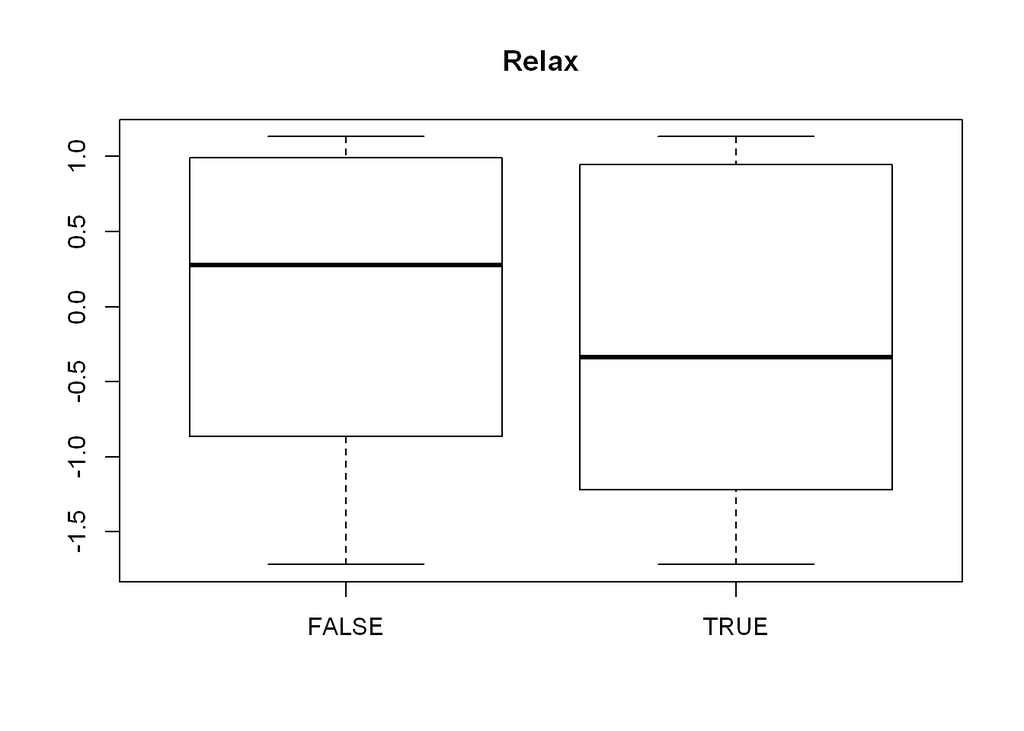

```r
boxplot(Goals$zgoalprogress ~ Goals$relaxgol, main = "Relax")
```

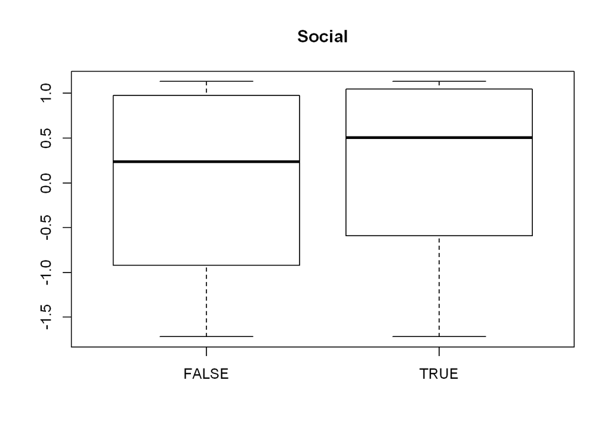

```r
boxplot(Goals$zgoalprogress ~ Goals$socgol, main = "Social")
```

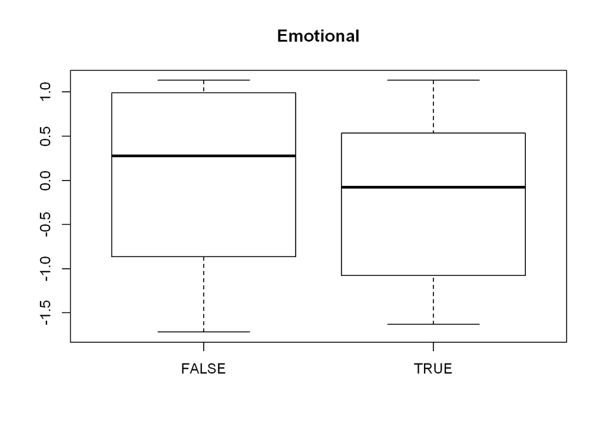

```r
boxplot(Goals$zgoalprogress ~ Goals$emogol, main = "Emotional")
```

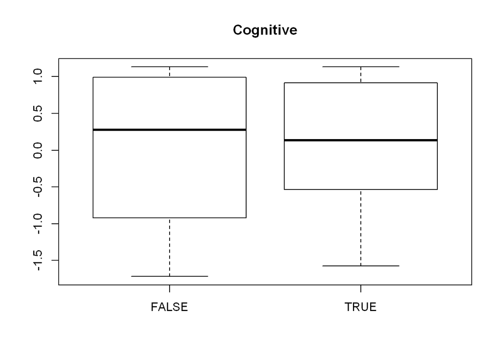

```r
boxplot(Goals$zgoalprogress ~ Goals$coggoal, main = "Cognitive")
```

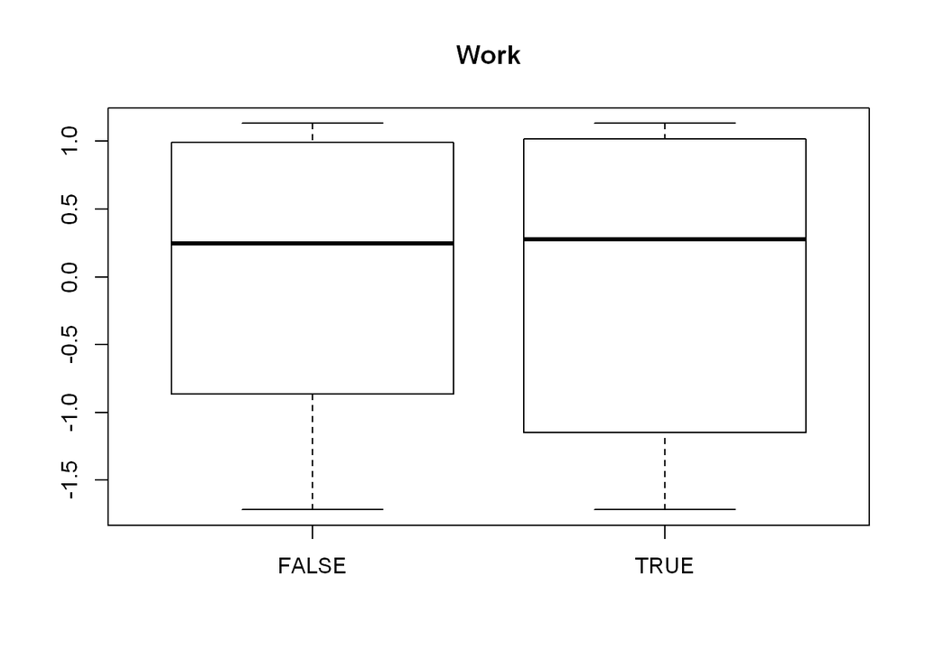

```r
boxplot(Goals$zgoalprogress ~ Goals$workgoal, main = "Work")
```

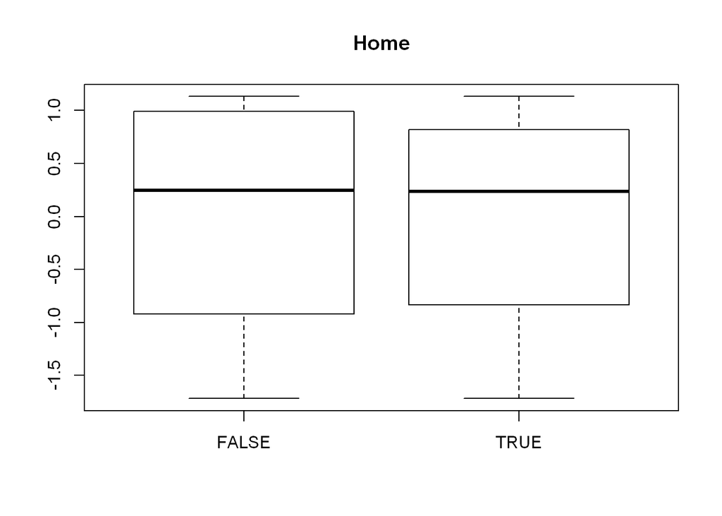

```r
boxplot(Goals$zgoalprogress ~ Goals$homegoal, main = "Home")
```

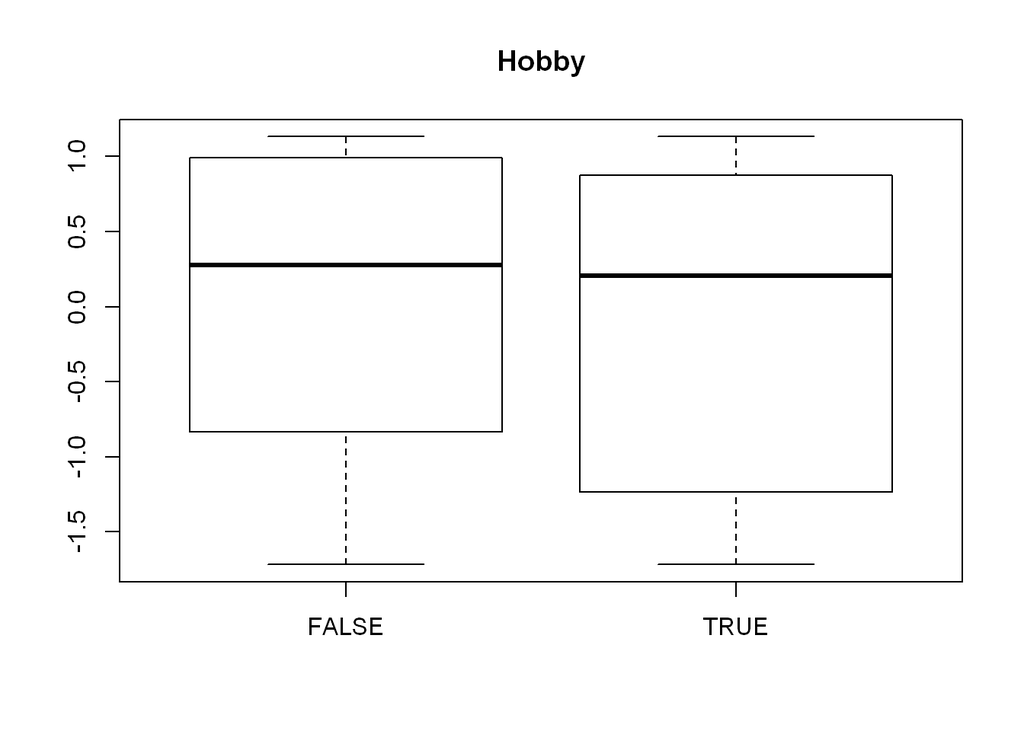

```r
boxplot(Goals$zgoalprogress ~ Goals$hobgoal, main = "Hobby")
```

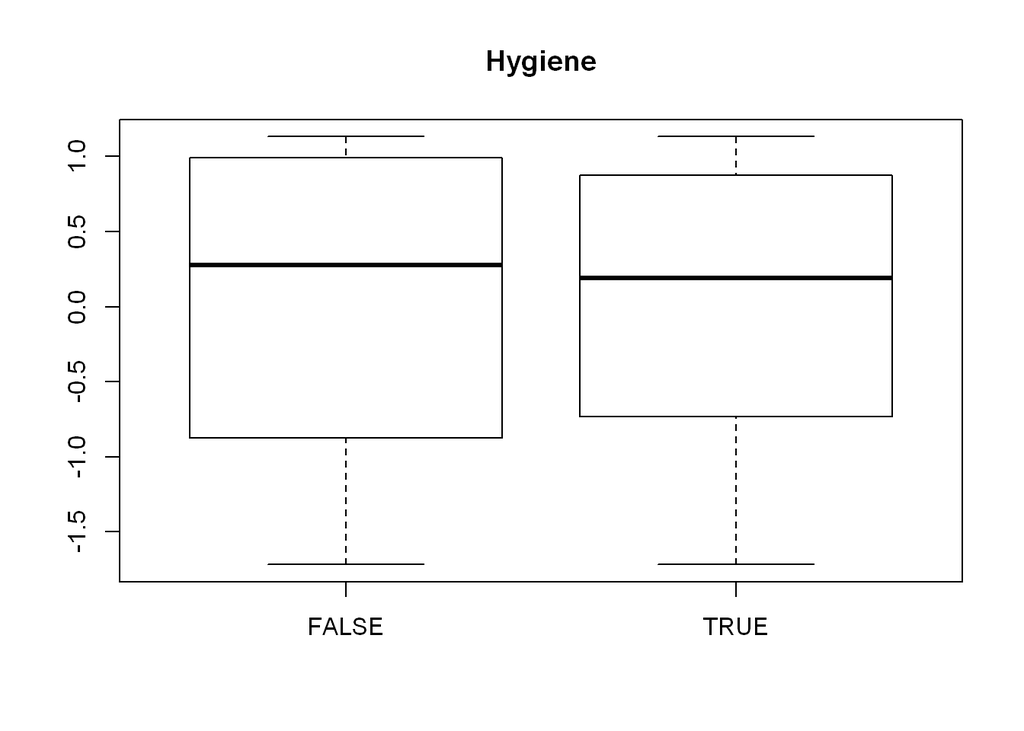

```r
boxplot(Goals$zgoalprogress ~ Goals$hygmdgol, main = "Hygiene")
```

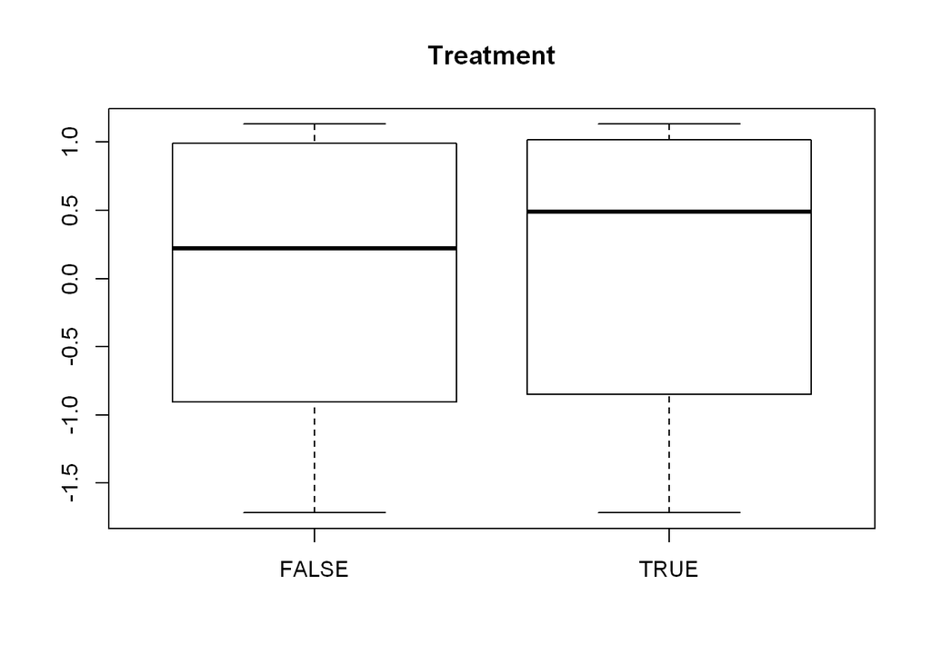

```r
boxplot(Goals$zgoalprogress ~ Goals$treatgol, main = "Treatment")
```

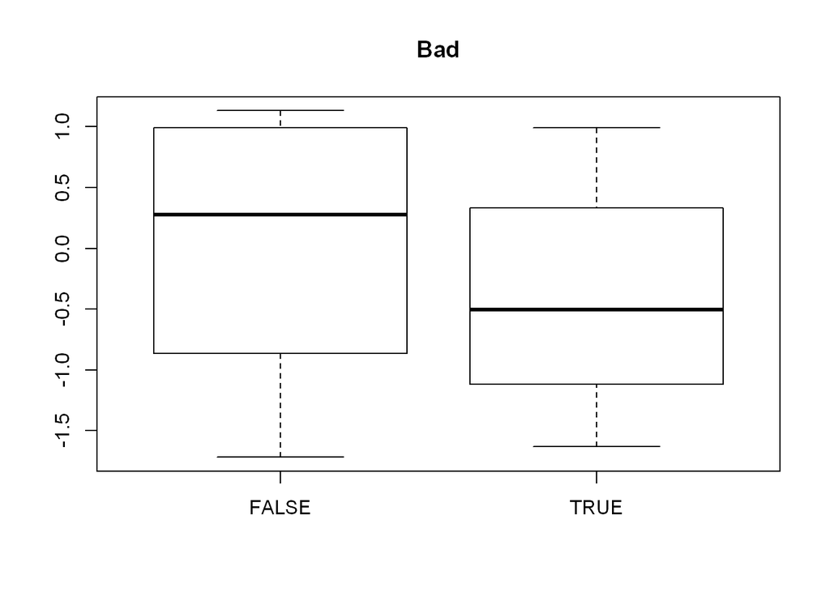

```r
boxplot(Goals$zgoalprogress ~ Goals$badgoal, main = "Bad")
```

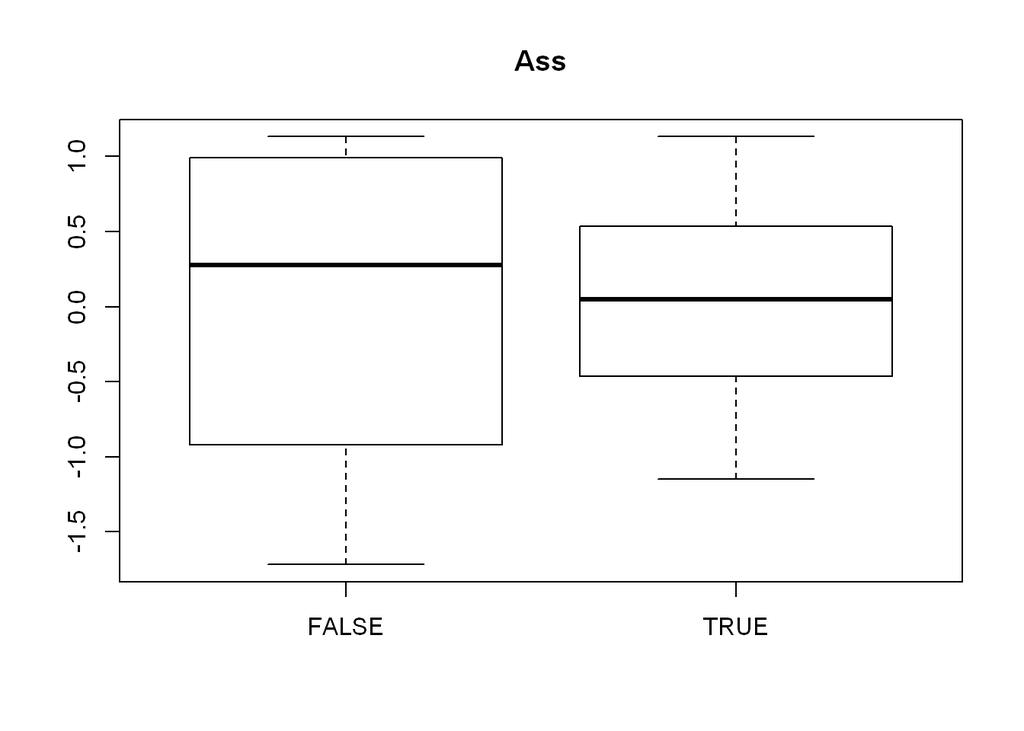

```r
boxplot(Goals$zgoalprogress ~ Goals$assgoal, main = "Ass")
```

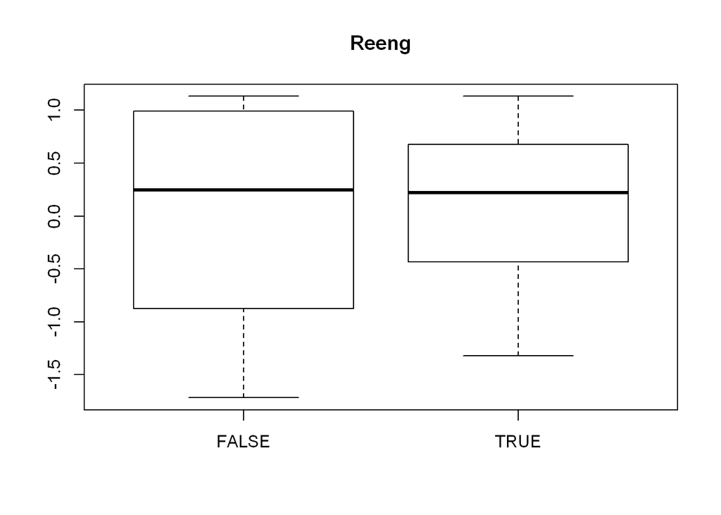

```r
boxplot(Goals$zgoalprogress ~ Goals$reenggol, main = "Reeng")
```

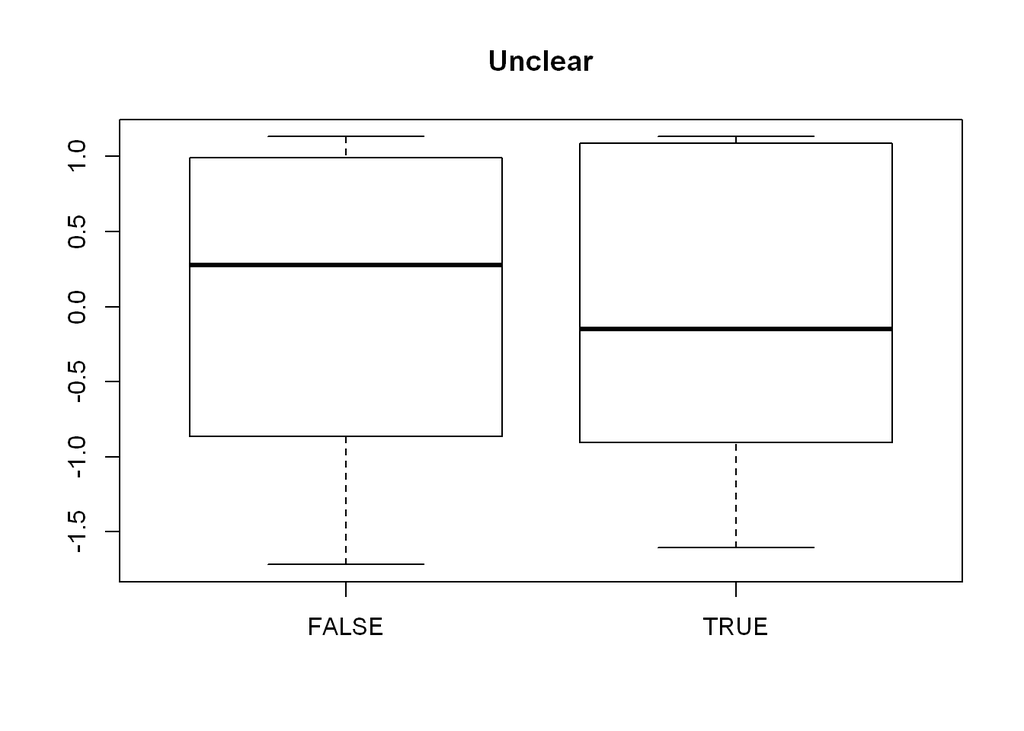

```r
boxplot(Goals$zgoalprogress ~ Goals$unclearg, main = "Unclear")
```

```r
model_goals <- lm(zgoalprogress ~ pagol+dietgol+alcogol+addictgol+sleepgol+relaxgol+socgol+emogol+coggoal+workgoal+homegoal+hobgoal+hygmdgol+treatgol+badgoal+assgoal+reenggol+unclearg, data = Goals)
summary(model_goals)
```

```
##
## Call:
## lm(formula = zgoalprogress ~ pagol + dietgol + alcogol + addictgol +
##     sleepgol + relaxgol + socgol + emogol + coggoal + workgoal +
##     homegoal + hobgoal + hygmdgol + treatgol + badgoal + assgoal +
##     reenggol + unclearg, data = Goals)
##
## Residuals:
##     Min      1Q  Median      3Q     Max
## -1.8699 -0.8351  0.2481  0.8990  1.7775
##
## Coefficients: (1 not defined because of singularities)
##               Estimate Std. Error t value Pr(>|t|)
## (Intercept)    0.06727    0.11559   0.582  0.56077
## pagolTRUE      0.06047    0.13127   0.461  0.64521
## dietgolTRUE   -0.63811    0.21836  -2.922  0.00360 **
## alcogolTRUE   -0.98074    0.70535  -1.390  0.16487
## addictgolTRUE  1.16180    0.41917   2.772  0.00574 **
## sleepgolTRUE  -0.39695    0.20119  -1.973  0.04892 *
## relaxgolTRUE        NA         NA      NA       NA
## socgolTRUE     0.08119    0.13300   0.610  0.54177
## emogolTRUE     0.07206    0.24659   0.292  0.77020
## coggoalTRUE    0.06716    0.20466   0.328  0.74290
## workgoalTRUE  -0.06597    0.16211  -0.407  0.68418
## homegoalTRUE  -0.07489    0.13505  -0.555  0.57941
## hobgoalTRUE   -0.20891    0.14680  -1.423  0.15518
## hygmdgolTRUE  -0.07589    0.26225  -0.289  0.77238
## treatgolTRUE   0.08154    0.13608   0.599  0.54923
## badgoalTRUE   -0.54138    0.25066  -2.160  0.03115 *
## assgoalTRUE   -0.09697    0.23304  -0.416  0.67748
## reenggolTRUE   0.13080    0.23351   0.560  0.57556
## uncleargTRUE  -0.02092    0.21433  -0.098  0.92229
## ---
## Signif. codes:  0 '***' 0.001 '**' 0.01 '*' 0.05 '.' 0.1 ' ' 1
##
## Residual standard error: 0.9833 on 650 degrees of freedom
##   (160 observations deleted due to missingness)
## Multiple R-squared:  0.04239,    Adjusted R-squared:  0.01734
## F-statistic: 1.692 on 17 and 650 DF,  p-value: 0.03967
```

## 1.b) Goal content and PHQ scores at end of treatment

Now obviously, our main concern is not goal progress but rather that patients reduce their depression symptoms. Therefore, let’s see which kind of goal is associated with the lowest scores at the end of the treatment. To get an idea of that, I will plot goals against depression scores at the end of treatment (phqend). Lower scores mean fewer/less intense symptoms, i.e. are more desirable.

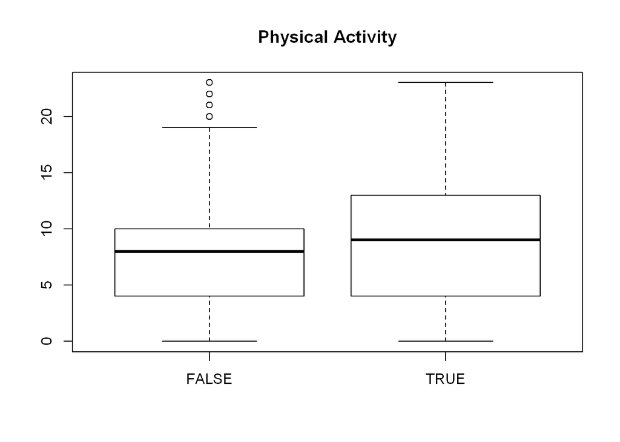

```r
boxplot(Goals$phqend ~ Goals$pagol, main = "Physical Activity")
```

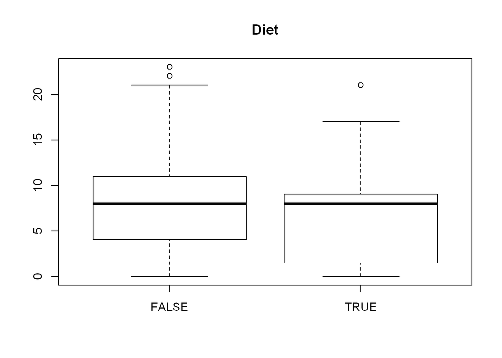

```r
boxplot(Goals$phqend ~ Goals$dietgol, main = "Diet")
```

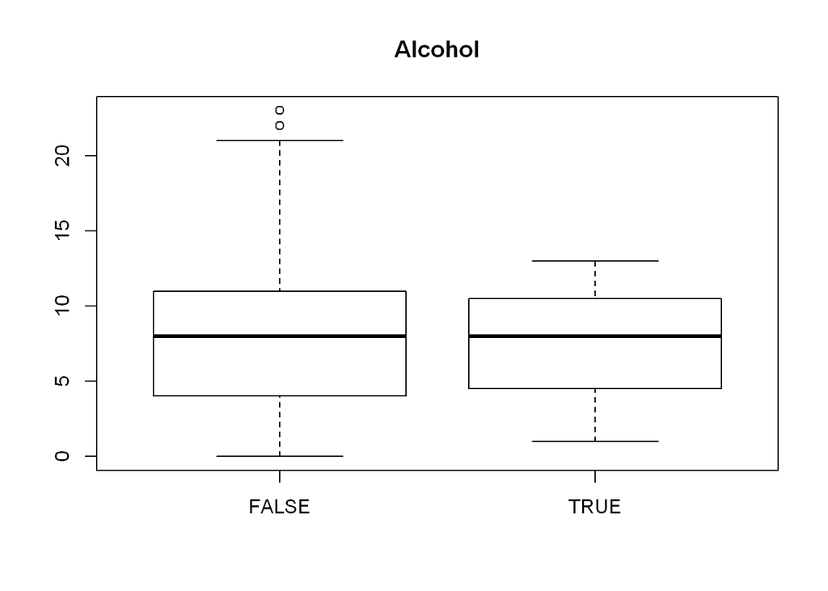

```r
boxplot(Goals$phqend ~ Goals$alcogol, main = "Alcohol")
```

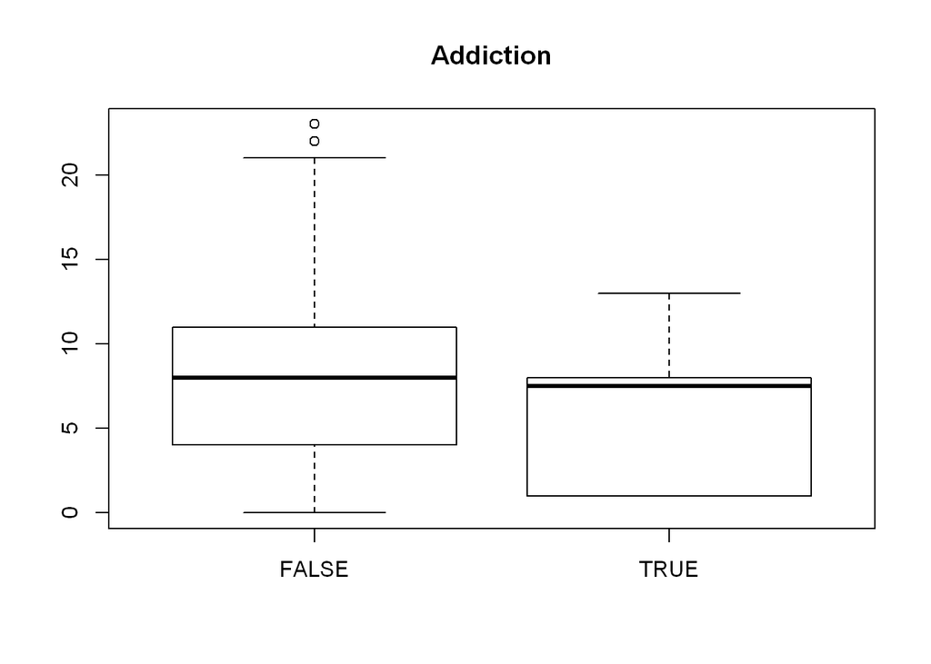

```r
boxplot(Goals$phqend ~ Goals$addictgol, main = "Addiction")
```

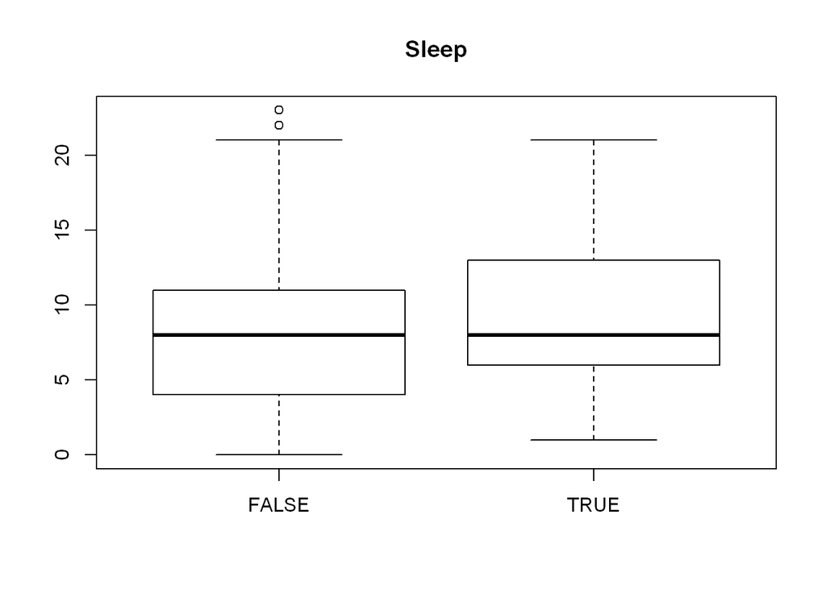

```r
boxplot(Goals$phqend ~ Goals$sleepgol, main = "Sleep")
```

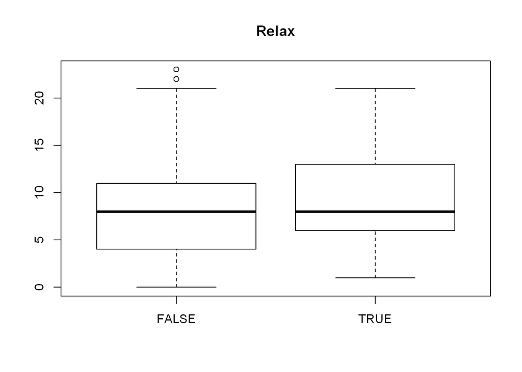

```r
boxplot(Goals$phqend ~ Goals$relaxgol, main = "Relax")
```

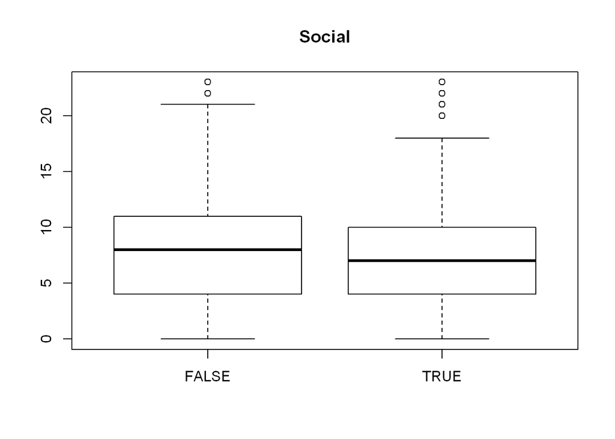

```r
boxplot(Goals$phqend ~ Goals$socgol, main = "Social")
```

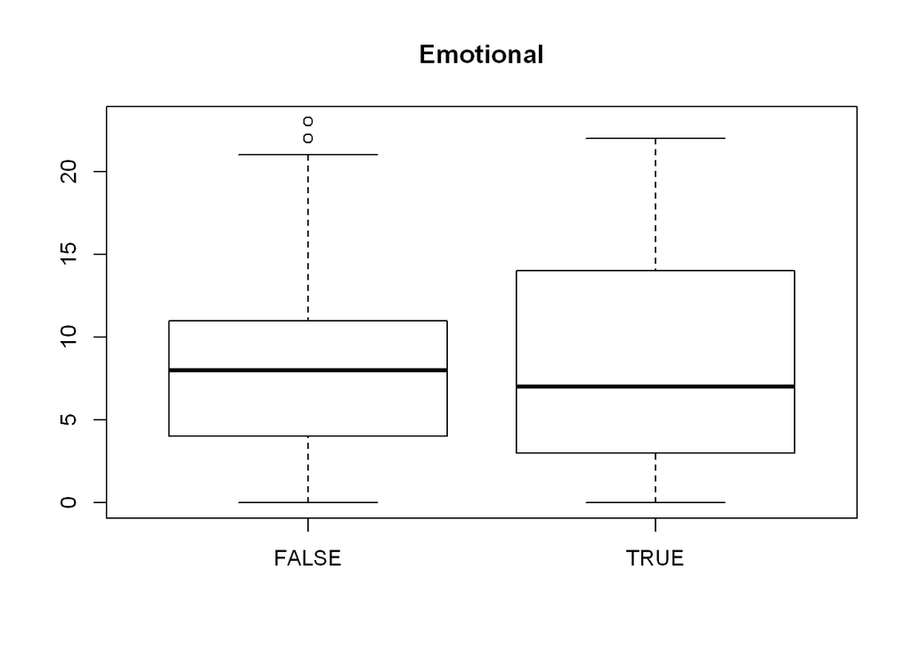

```r
boxplot(Goals$phqend ~ Goals$emogol, main = "Emotional")
```